# ICPE Pre-Conference Course

Let’s git it started

Janick Weberpals, RPh, PhD

jweberpals.academic@gmail.com

August 23, 2025

# Welcome to ICPE 2025

## Meet Your Faculty

Janick Weberpals,  
RPh, PhD

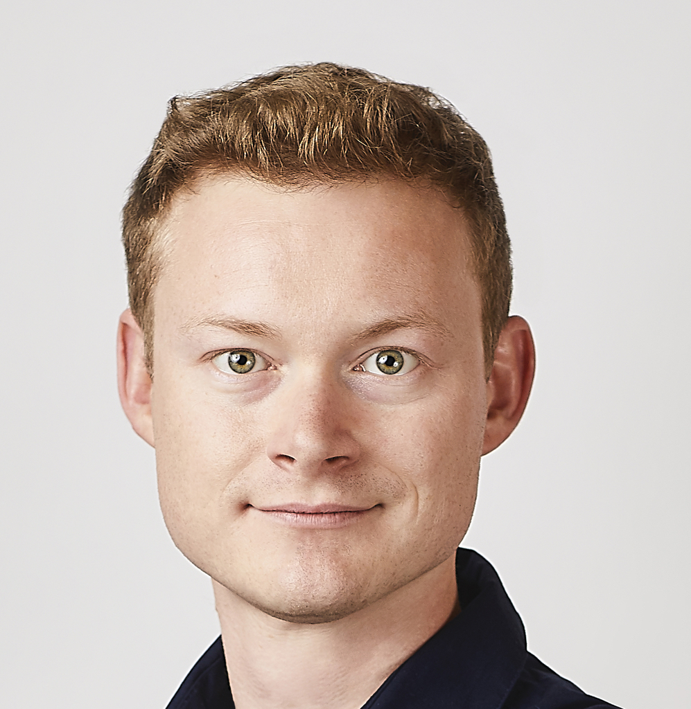

Associate Director, Oncology Data Science & AI, AstraZeneca

Shirley Wang,  
PhD

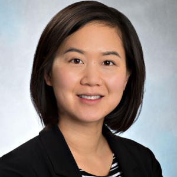

Associate Professor, Brigham & Women’s Hospital, Harvard Medical School

Anna Schultz  
PhD, MSc

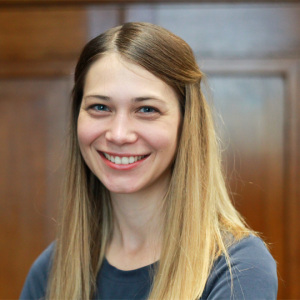

Assistant Professor, London School for Hygiene and Tropical Medicine

John Tazare,  
PhD

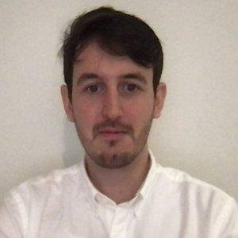

Assistant Professor, London School for Hygiene and Tropical Medicine

## Disclosures

**Disclosure**

- JW is an employee at AstraZeneca and own shares in AstraZeneca. The views and opinions expressed in this presentation are those of the author and do not necessarily reflect the official policy or position of AstraZeneca. The author is presenting in a personal capacity.
- SVW has been an ad hoc consultant to Cytel Inc, MITRE a federally funded research and development center for the Centers for Medicare and Medicaid Services, and the ACI Group for unrelated work.
- AS is employed by LSHTM on a research grant funded by GSK.
- JT has no disclosures.

# Introduction to the topic

## Transparency and reproducibility standards across the RWE lifecycle

**Study conceptualization** and pre-specification using HARPER<sup>1</sup>

[figure not shown]

Figure 1: HARPER protocol template

**Study implementation**  
guidelines, training and engagement are lacking in non-interventional healthcare research community

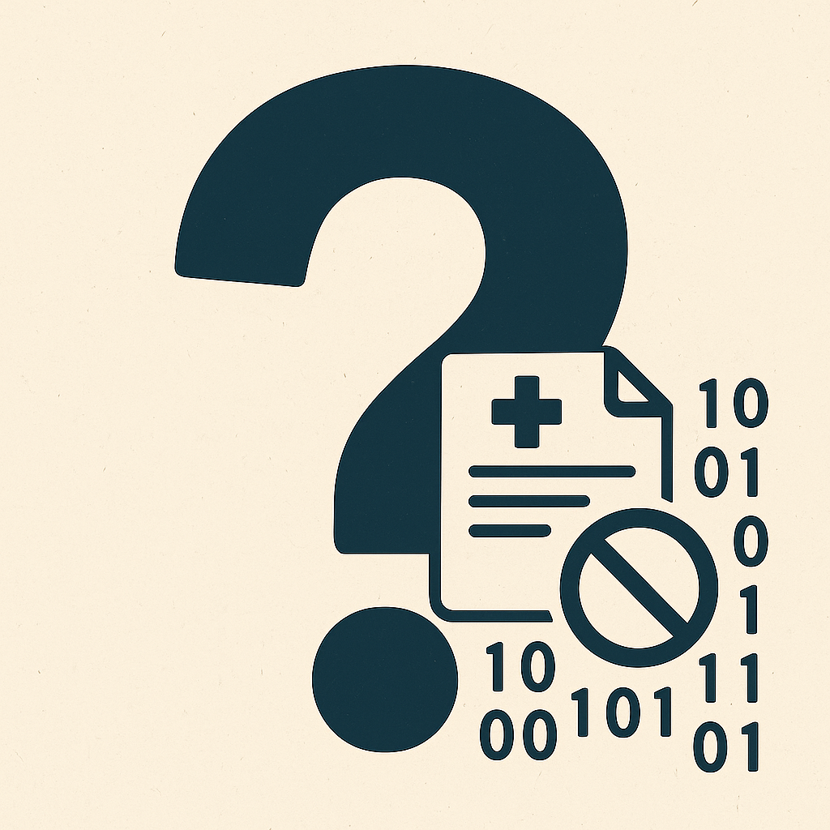

Figure 2: Study implementation resources are still lacking (*illustration generated by GPT*).

**Study reporting**  
guidelines like [RECORD(-PE)](https://www.record-statement.org)<sup>2</sup> and [STROBE](https://www.strobe-statement.org)<sup>3</sup>

[figure not shown]

Figure 3: RECORD(-PE) study reporting

[figure not shown]

Figure 4: STROBE study reporting

## Our agenda today

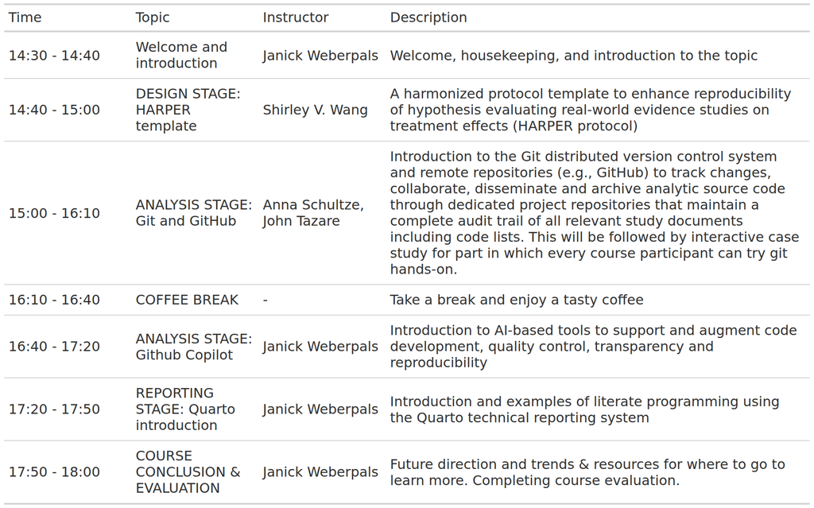

Table 1: Course timetable.

## Course materials

You can find all course materials, setup instructions and further useful resources at:

https://janickweberpals.github.io/icpe-git-2025/

[figure not shown]

Figure 5: Landing page of [ICPE 2025 course website](https://janickweberpals.github.io/icpe-git-2025/).

## PDS Special Issue

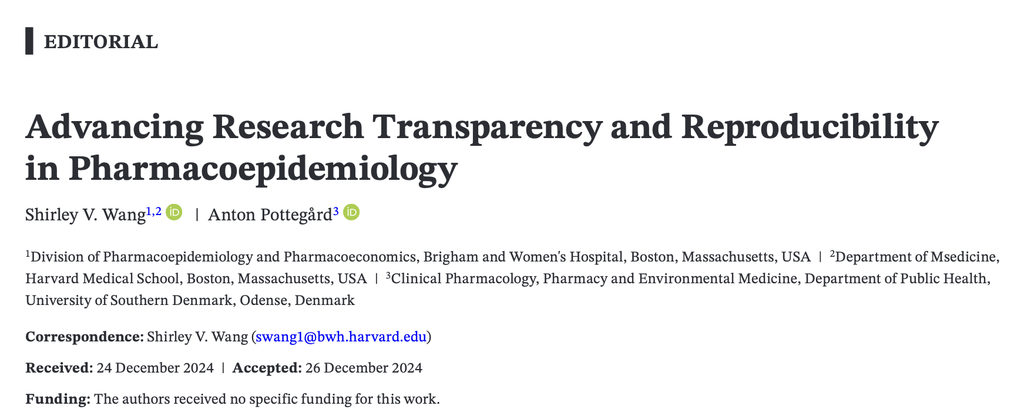

Figure 6: PDS Special Issue on Transparency and Reproducibility in Pharmacoepidemiology<sup>4</sup>

## Technical Setup

[figure not shown]

Figure 7: Link to course website section with step-by-step instructions on technical setup for this course.

## Important: Course evaluation

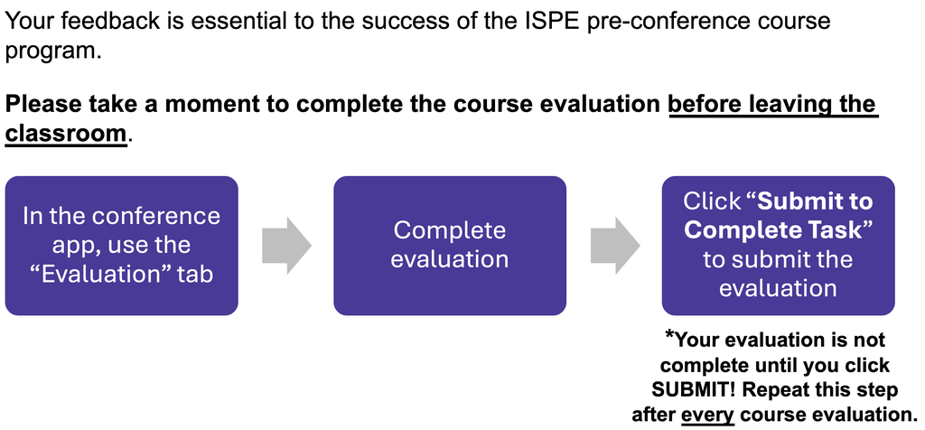

Figure 8: Instructions to complete the course eveluation in the conference app.

## Course focus

**What this course is about**

- Giving recommendations on how to enhance transparency and reproducibility across different stages of a RWE study implementation
- What to consider when pre-specifying your study design and analyses
- Version control of analytic code and computational reproducibility
- Making your study report more transparent to others & future you

**What this course is NOT about**

- Any specific programming language
- Statistical programming language bootcamp
- Any specific study design or statistical analysis considerations

## Why is this important?

Increasing expectations and policies from various stakeholders regarding the provenance, sharing and audit trial of study documents including analytic code

- **Regulatory**

> “Sponsors should ensure that RWD and associated programming codes and algorithms submitted to FDA are documented, well-annotated, and complete, which would allow FDA to replicate the study analysis using the same dataset and analytic approach” (FDA<sup>5</sup>)
- **Publishing**

> “We will make code sharing mandatory too.” (BMJ<sup>6</sup>)

## References

1.

Wang SV, Pottegård A, Crown W, *et al.* HARmonized protocol template to enhance reproducibility of hypothesis evaluating real-world evidence studies on treatment effects: A good practices report of a joint ISPE/ISPOR task force. *Value in Health* 2022; **25**: 1663–1672.

2.

Benchimol EI, Smeeth L, Guttmann A, *et al.* The REporting of studies conducted using observational routinely-collected health data (RECORD) statement. *PLoS medicine* 2015; **12**: e1001885.

3.

Von Elm E, Altman DG, Egger M, *et al.* The strengthening the reporting of observational studies in epidemiology (STROBE) statement: Guidelines for reporting observational studies. *International journal of surgery* 2014; **12**: 1495–1499.

4.

Wang SV, Pottegård A. Advancing research transparency and reproducibility in pharmacoepidemiology. *Pharmacoepidemiology and Drug Safety* 2025; **34**: e70096.

5.

US food and drug administration. Considerations for the use of real-world data and real-world evidence to support regulatory decision-making for drug and biological products. 2023. Available at: https://www.fda.gov/regulatory-information/search-fda-guidance-documents/considerations-use-real-world-data-and-real-world-evidence-support-regulatory-decision-making-drug.

6.

Abbasi K. A commitment to act on data sharing. *BMJ* 2023; **382**: p1609. Available at: https://www.bmj.com/content/382/bmj.p1609.